# Basis functions approximations for reduced-rank Gaussian process regresion: The uni-dimensional case

### Smooth splines model

We are going to fit a smooth spline model (using function ‘s’ of the R-package ‘mgcv’) in order to do comparison to the Basis function approach.

The function ‘make_standata’ of the R-package ‘brms’ is used to get the data. A bunch of datasets, one for each one of the different number of knots $kn$, are obtained for this smooth spline model.

```r
kn <- c(2,3,4,6,8,10,15,20)  #different number of knots

standata_SP <- list()
for(j in 1:length(kn)){  #different number of knots
    standata_SP[[j]] <- make_standata(y ~ s(x, k=2+kn[j]), data= data.frame(x= x, y= y))
    standata_SP[[j]]$N1 <- N1
    standata_SP[[j]]$ind1 <- ind1
}
```

In the same way, the function ‘make_stancode’ of the R-package ‘brms’ is used to build the main body of the Stan code for this smooth spline model.

```r
stancode_SP <- make_stancode(y ~ s(x, k=2+2), data= data.frame(x= x, y= y))
```

Then, the code is polished to be adapted to the data, yielding to the final code: ‘https://github.com/gabriuma/basis_functions_approach_to_GP/blob/master/uni_dimensional/simulated_dataset/stancode_SP_1dim.stan’

Adjust the model using Stan software and the function ‘stan’ from the R-package ‘rstan’. Different adjustments are performed, one for each one of the different numbers of knots.

```r
stanout_SP <- list()
for(j in 1:length(kn)){  #different number of knots
    stanout_SP[[j]] <- stan(file = ".../stancode_SP_1dim.stan", data= standata_SP[[j]], iter= 2000,  warmup= 1000, chains= 1, thin= 1, algorithm= "NUTS")
}
```

Store the posteriors distribution of the latent function $f$, the predictive distribution for training and test data, and the log predictive densities for the test data, as well as the parameters $sds_1_1$ and $sigma$ of the spline model. Plots for these two parameters, $sds_1_1$ and $sigma$, as a function of the number of knots $kn$ are conputed.

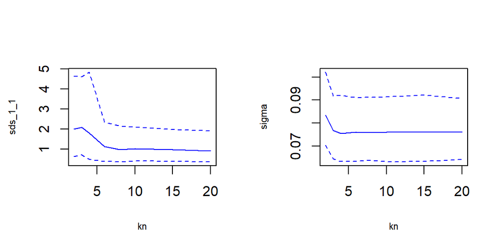

```r
f_SP <- list()
y_SP <- list()
log_y_SP <- list()
sds_1_1_SP <- matrix(NA,length(kn),8)
sigma_SP <- matrix(NA,length(kn),8)

par(mfcol=c(1,2))
for(j in 1:length(kn)){  #different number of knots
    f_SP[[j]] <- summary(stanout_SP[[j]], pars = c("mu"), probs = c(0.025, 0.5, 0.975), digits_summary = 4)$summary
    y_SP[[j]] <- summary(stanout_SP[[j]], pars = c("y_predict"), probs = c(0.025, 0.5, 0.975), digits_summary = 4)$summary
    log_y_SP[[j]] <- summary(stanout_SP[[j]], pars = c("log_y_predict"), probs = c(0.025, 0.5, 0.975), digits_summary = 4)$summary
    sds_1_1_SP[j,] <- summary(stanout_SP[[j]], pars = c("sds_1_1"), probs = c(0.025, 0.5, 0.975), digits_summary = 4)$summary
    sigma_SP[j,] <- summary(stanout_SP[[j]], pars = c("sigma"), probs = c(0.025, 0.5, 0.975), digits_summary = 4)$summary
}

matplot(kn,sds_1_1_SP[,c(1,4,6)], xlab="kn", type="l", lty=c(1,2,2), col=4, ylab="sds_1_1", cex.lab=0.7)
matplot(kn,sigma_SP[,c(1,4,6)], xlab="kn", type="l", lty=c(1,2,2), col=4, ylab="sigma", cex.lab=0.7)
```

Histogram plots of the parameters $sds_1_1$ and $sigma$.

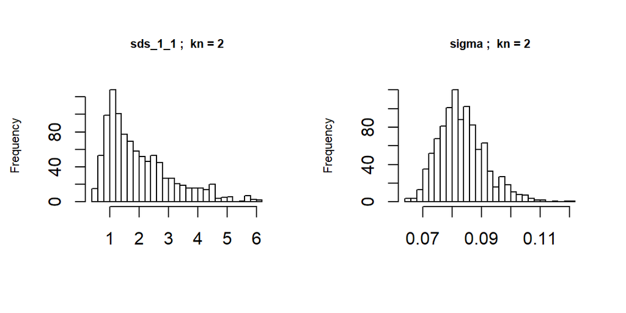

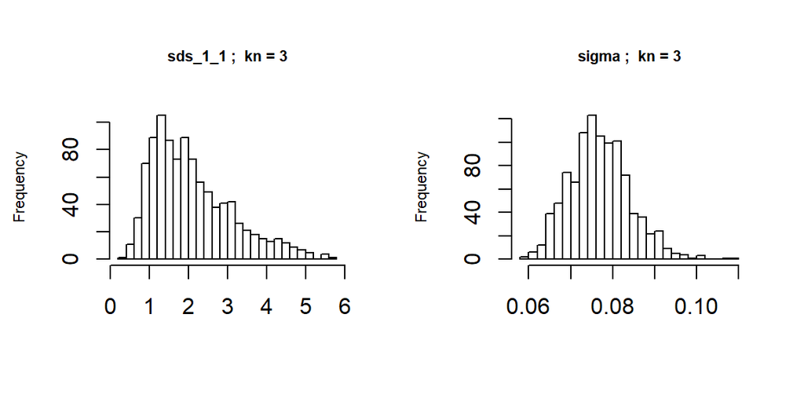

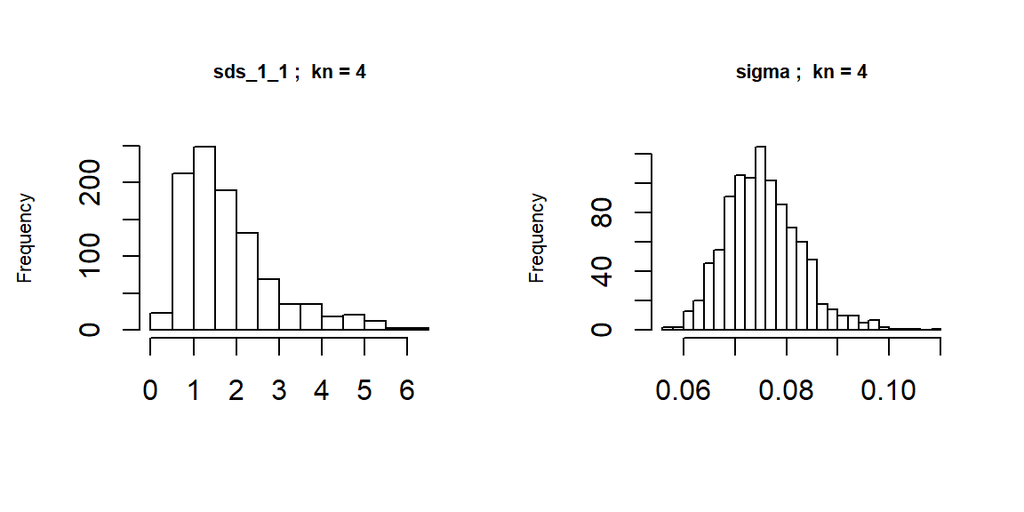

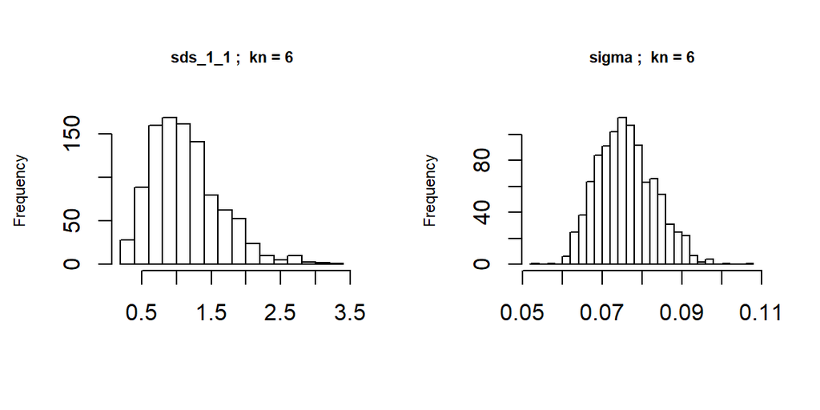

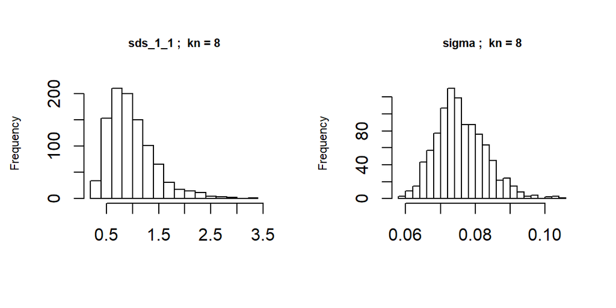

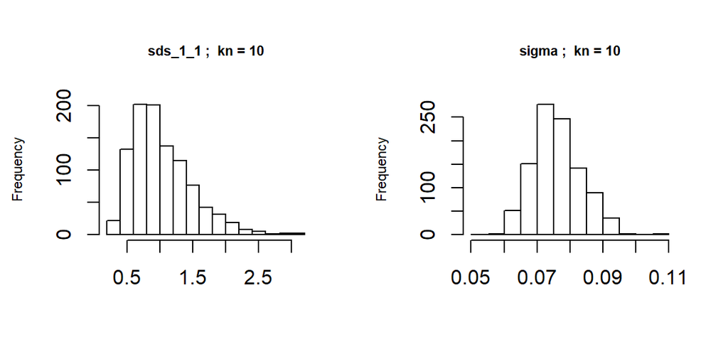

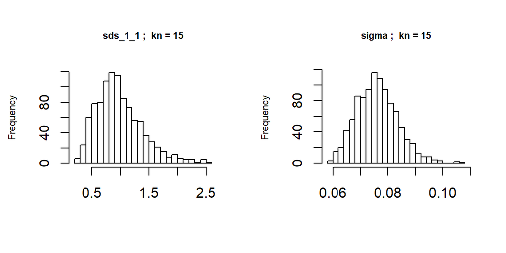

```r
par(mfrow=c(1,2))
for(j in 1:length(M)){
    hist(extract(stanout_SP[[j]], pars=c("sds_1_1"))$sds_1_1, main=paste("sds_1_1 ;  kn =",kn[j]), xlab="", cex.lab=0.7, cex.main=0.7, breaks=20)
      hist(extract(stanout_SP[[j]], pars=c("sigma"))$sigma, main=paste("sigma ;  kn =",kn[j]), xlab="", cex.lab=0.7, cex.main=0.7, breaks=20)
}
```

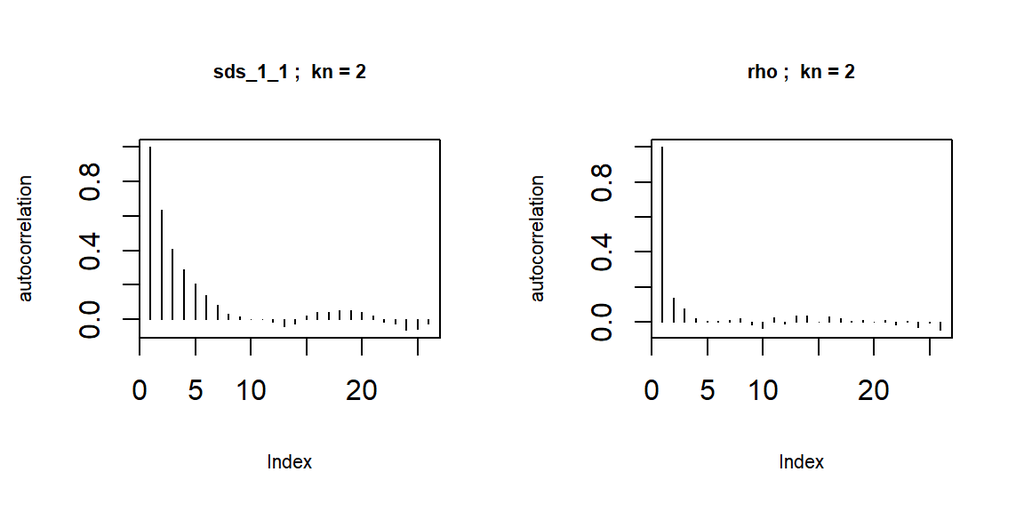

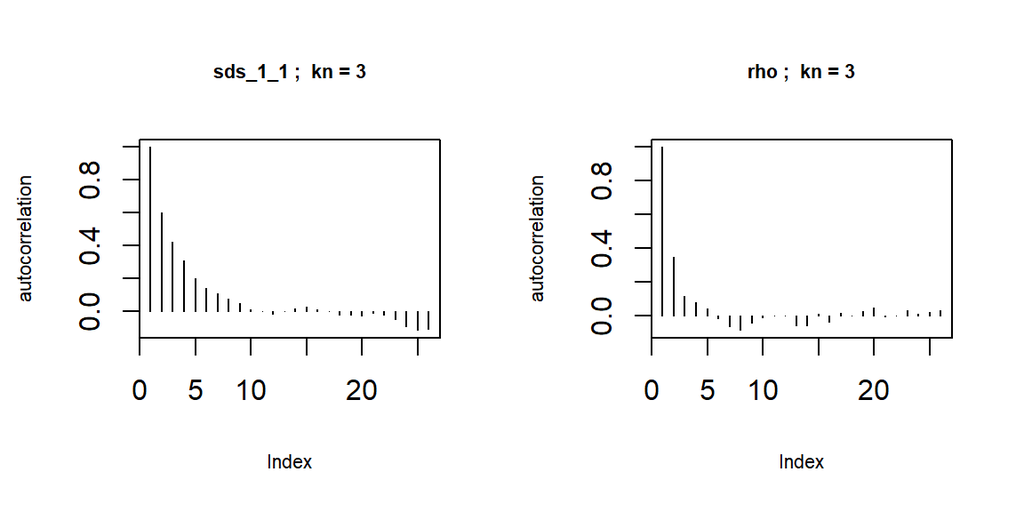

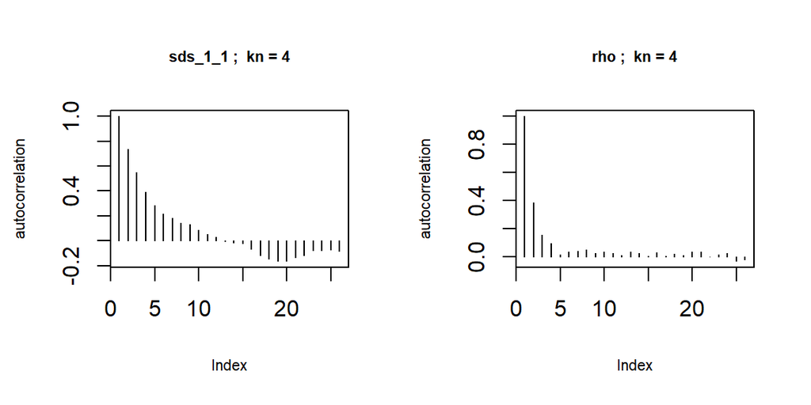

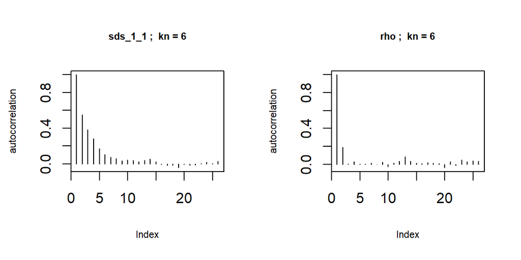

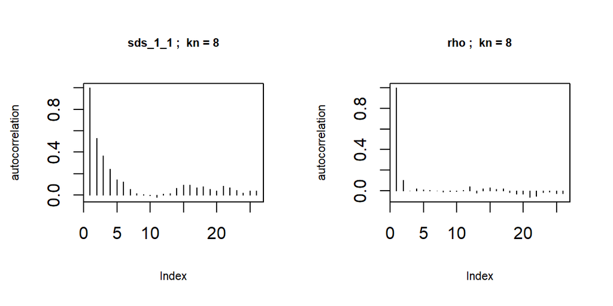

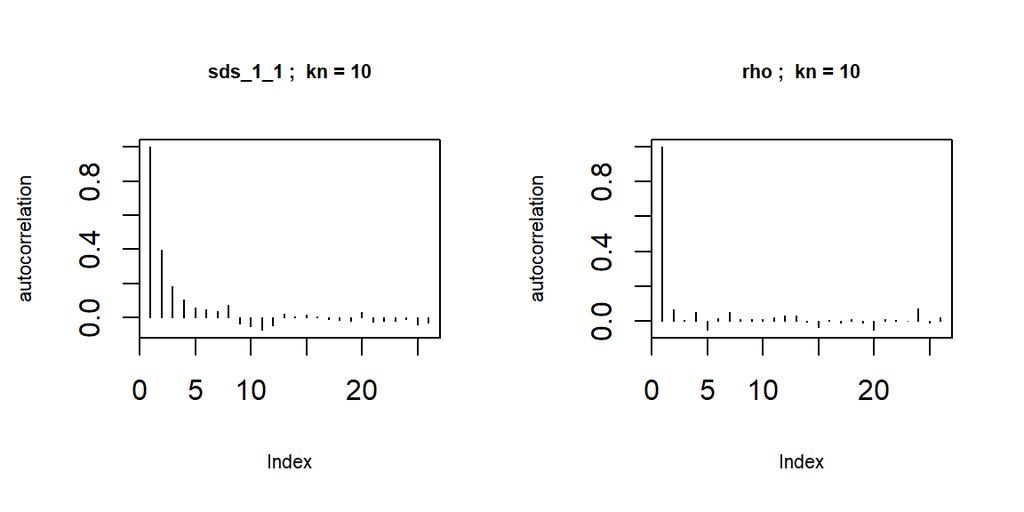

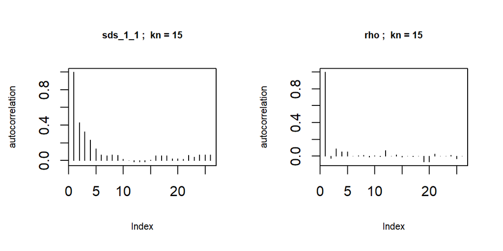

```r
par(mfcol=c(1,2))
for(j in 1:length(M)){
    plot(stan_ac(stanout_SP[[j]], pars = c("sds_1_1"))$data$ac, type="h", ylab="autocorrelation", main=paste("sds_1_1 ;  kn =",kn[j]), cex.main=0.7, cex.lab=0.7)
      plot(stan_ac(stanout_SP[[j]], pars = c("sigma"))$data$ac, type="h", ylab="autocorrelation", main=paste("rho ;  kn =",kn[j]), cex.main=0.7, cex.lab=0.7)
}
```

```r
mse_SP <- vector()
elpd_SP <- vector()
time_SP <- vector()
neff_zs_1_1_SP <- vector()
neff_sds_1_1_SP <- vector()
neff_sigma_SP <- vector()
neff_f_SP <- vector()

for(j in 1:length(kn)){  #different number of knots
  mse_SP[j] <- sqrt(sum((y[ind2] - y_SP[[j]][ind2,1])^2)/N2)
  elpd_SP[j] <- sum(log_y_SP[[j]][ind2,1])/N2
  time_SP[j] <- get_elapsed_time(stanout_SP[[j]])[2]/(stanout_SP[[j]]@sim$iter - stanout_SP[[j]]@sim$warmup)

  neff_sds_1_1_SP[j] <- sds_1_1_SP[j,7]/(stanout_SP[[j]]@sim$iter - stanout_SP[[j]]@sim$warmup)
  neff_f_SP[j] <- mean(f_SP[[j]][,7])/(stanout_SP[[j]]@sim$iter - stanout_SP[[j]]@sim$warmup)
  neff_sigma_SP[j] <- mean(sigma_SP[j,7])/(stanout_SP[[j]]@sim$iter - stanout_SP[[j]]@sim$warmup)
}
```

In the following figure, we show the posterior values of the latent function $f$ for training and test data, as function of the number of knots $kn$, jointly with the posteriors of the Basis functions approach model and the full Gaussian process model. The vertical grey dashed line divide the training and test data sets.

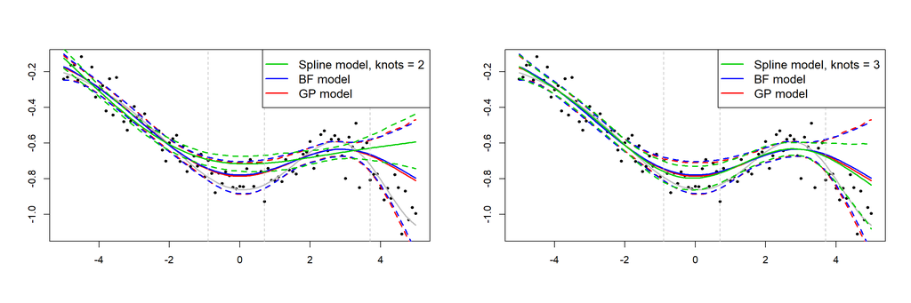

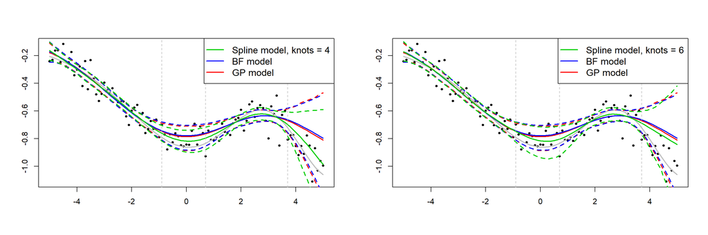

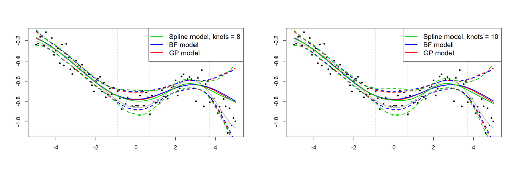

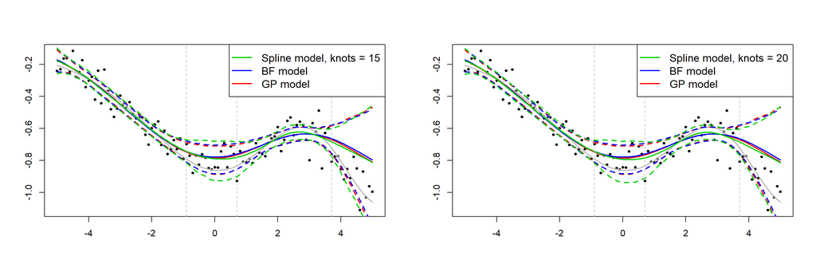

```r
par(mfrow=c(1,2))
for(j in 1:length(kn)){  #different number of knots
  # True function and observations
  plot(x, y, cex=0.6, pch=19, xlab="", ylab="", cex.axis=1)
  lines(x, F(x), lwd=2, col="grey")
  # GP model
  matplot(x, cbind(f_GP[,1],f_GP[,c(4,6)]), add=TRUE, col=2, type="l", lwd=2, lty=c(1,2,2))
  # BF model
  matplot(x, cbind(f_BF[[5]][,1],f_BF[[5]][,c(4,6)]), add=TRUE, col=4, type="l", lwd=2, lty=c(1,2,2))
  # SP model
  matplot(x, cbind(f_SP[[j]][,1],f_SP[[j]][,c(4,6)]), add=TRUE, col="green3", type="l", lwd=2, lty=c(1,2,2))

  abline(v=c(x[ind2[1]],x[ind2[17]],x[ind1[N1]]), lty=2, col="grey")
  legend("topright", legend=c(paste("Spline model, knots =",kn[j]),"BF model","GP model"), lty=c(1), lwd=c(2), pch=c(NA), pt.cex=c(NA), col=c("green3", 4, 2), cex=1.2)
}
```

### MSE, ELPD, computation time and effective number of samples

Mean square error as a function of the number of basis functions, in the case of the Basis function model, and as a function of knots, in the case of the Splines model.

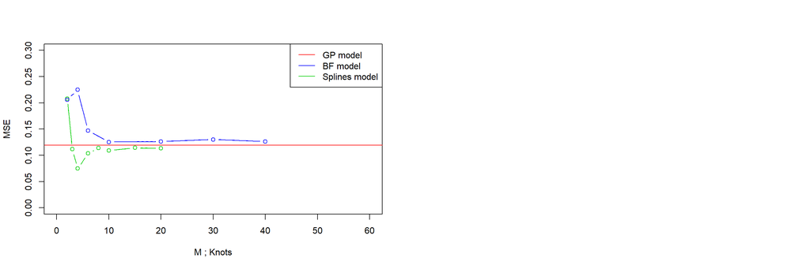

```r
par(mfrow=c(1,2))

matplot(kn, mse_SP[1:length(kn)], type="b", col="green3", lwd=1, lty=1, pch=1, xlab="M ; Knots", ylab="MSE", xlim=c(0,60), ylim=c(0,0.30))
matplot(kn, mse_SP[1:length(kn)], type="b", col="green3", lwd=1, lty=2, pch=1, add=TRUE)
matplot(kn, mse_SP[1:length(kn)], type="b", col="green3", lwd=1, lty=2, pch=1, add=TRUE)

matplot(M, mse_BF[1:length(M)], type="b", col=4, lwd=1, lty=1, pch=1, add=TRUE)
matplot(M, mse_BF[1:length(M)], type="b", col=4, lwd=1, lty=2, pch=1, add=TRUE)
matplot(M, mse_BF[1:length(M)], type="b", col=4, lwd=1, lty=2, pch=1, add=TRUE)

abline(h= mse_GP, col=2, lwd=1, lty=1)
abline(h= mse_GP, lwd=1, col=2, lty=2)
abline(h= mse_GP, lwd=1, col=2, lty=2)

legend("topright", legend=c("GP model","BF model","Splines model"), col=c(2,4,"green3"), lty=c(1,1,1), lwd=1)
```

Expected log predictive density as a function of the number of basis functions, in the case of the Basis function model, and as a function of knots, in the case of the Splines model.

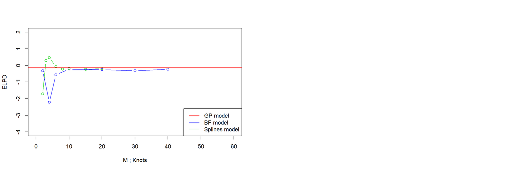

```r
par(mfrow=c(1,2))

matplot(kn, elpd_SP[1:length(kn)], type="b", col="green3", lwd=1, lty=1, pch=1, xlab="M ; Knots", ylab="ELPD", xlim=c(0,60), ylim=c(-4,2))

matplot(M, elpd_BF[1:length(M)], type="b", col=4, lwd=1, lty=1, pch=1, ylim=c(-15,4), add=TRUE)

abline(h= elpd_GP, col=2, lwd=1, lty=1)

legend("bottomright", legend=c("GP model","BF model","Splines model"), col=c(2,4,"green3"), lty=c(1,1,1), lwd=1)
```

Time-consuming of the models as a function of the number of basis functions in the case of the Basis functions model, and as a function of the knots in the case of the Splines model.

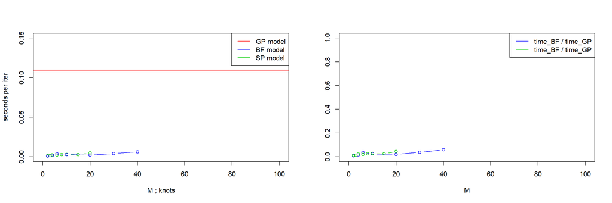

```r
par(mfrow=c(1,2))

matplot(kn[1:8], time_SP[1:length(kn[1:8])], type="b", col="green3", lwd=1, lty=1, pch=1,xlab="M ; knots", ylab="seconds per iter", ylim=c(0,0.15), xlim=c(0,100))
matplot(M, time_BF[1:length(M)], type="b", col=4, lty=1, pch=1, add=TRUE)
abline(h= time_GP, col=2, lty=1)

legend("topright", legend=c("GP model","BF model","SP model"), col=c(2,4,"green3"), lty=c(1,1,1), lwd=1)

matplot(M, time_BF[1:length(M)]/time_GP, type="b", col=4, lty=1, pch=1, ylab="", xlab="M", xlim=c(0,100), ylim=c(0,1))
matplot(kn, time_SP[1:length(kn)]/time_GP, type="b", col="green3", lty=1, pch=1, ylab="time_SP / time_GP", xlab="knots", xlim=c(0,100), ylim=c(0,1), add=TRUE)

legend("topright", legend=c("time_BF / time_GP", "time_BF / time_GP"), col=c(4,"green3"), lty=c(1), lwd=1)
```

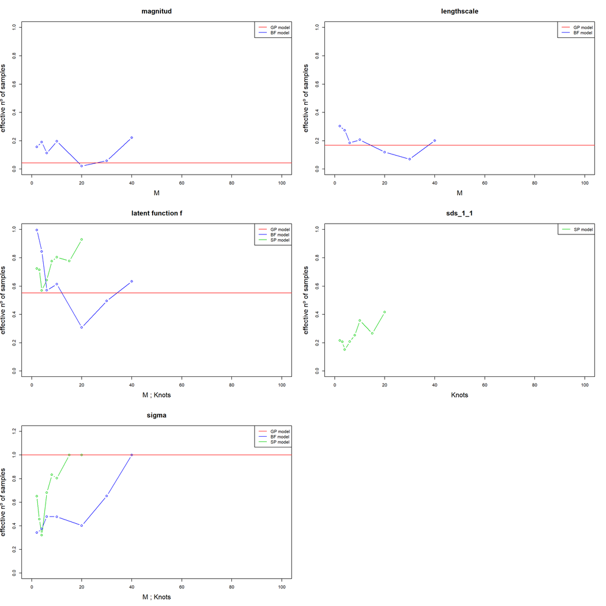

```r
par(mfrow=c(3,2))
# alpha (magnitud)
matplot(M, neff_alpha_BF[1:length(M)], type="b", col=4, lwd=1, lty=1, pch=1, ylim=c(0,1), ylab="effective nº of samples", main="magnitud", xlab="M", xlim=c(0,100), cex.lab=1.5, cex.main=1.5)
abline(h= neff_alpha_GP, col=2, lwd=1, lty=1)
legend("topright", legend=c("GP model","BF model"), col=c(2,4,"green3"), lty=c(1,1,1), lwd=1)

# rho (lengthscale)
matplot(M, neff_rho_BF[1:length(M)], type="b", col=4, lwd=1, lty=1, pch=1, ylim=c(0,1), ylab="effective nº of samples", main="lengthscale", xlab="M", xlim=c(0,100), cex.lab=1.5, cex.main=1.5)
abline(h= neff_rho_GP, col=2, lwd=1, lty=1)
legend("topright", legend=c("GP model","BF model"), col=c(2,4,"green3"), lty=c(1,1,1), lwd=1)

# latent function f
matplot(M, neff_f_BF[1:length(M)], type="b", col=4, lwd=1, lty=1, pch=1, ylim=c(0,1), ylab="effective nº of samples", main="latent function f", xlab="M ; Knots", xlim=c(0,100), cex.lab=1.5, cex.main=1.5)
matplot(kn, neff_f_SP[1:length(kn)], type="b", col="green3", lwd=1, lty=1, pch=1,add=TRUE)
abline(h= neff_f_GP, col=2, lwd=1, lty=1)
legend("topright", legend=c("GP model","BF model","SP model"), col=c(2,4,"green3"), lty=c(1,1,1), lwd=1)

# sds_1_1
matplot(kn, neff_sds_1_1_SP[1:length(kn)], type="b", col="green3", lwd=1, lty=1, pch=1, ylim=c(0,1), ylab="effective nº of samples", main="sds_1_1", xlab="Knots", xlim=c(0,100), cex.lab=1.5, cex.main=1.5)
legend("topright", legend=c("SP model"), col=c("green3"), lty=c(1,1,1), lwd=1)

# sigma
matplot(kn, neff_sigma_SP[1:length(kn)], type="b", col="green3", lwd=1, lty=1, pch=1, ylim=c(0,1.2), ylab="effective nº of samples", main="sigma", xlab="M ; Knots", xlim=c(0,100), cex.lab=1.5, cex.main=1.5)
matplot(M, neff_sigma_BF[1:length(M)], type="b", col="4", lwd=1, lty=1, pch=1, add=TRUE)
abline(h= neff_sigma_GP, col=2, lwd=1, lty=1)
legend("topright", legend=c("GP model","BF model","SP model"), col=c(2,4,"green3"), lty=c(1,1,1), lwd=1)
```

## Real Gay-data set

This dataset (‘https://github.com/gabriuma/basis_functions_approach_to_GP/blob/master/uni_dimensional/gay_dataset/gay_sum.rData’) relates the proportion of support for same-sex marriage to the age.

```r
load(".../gay_sum.rData")
str(gay_sum[[1]])
```

```
## 'data.frame':    74 obs. of  3 variables:
##  $ n  : int  251 186 163 218 214 270 306 336 271 308 ...
##  $ y  : int  122 93 77 101 97 125 140 170 134 125 ...
##  $ age: num  18 19 20 21 22 23 24 25 26 27 ...
```

$y$ are the counts and $n$ the trials of these binomial observations. $age$ is a covariate.

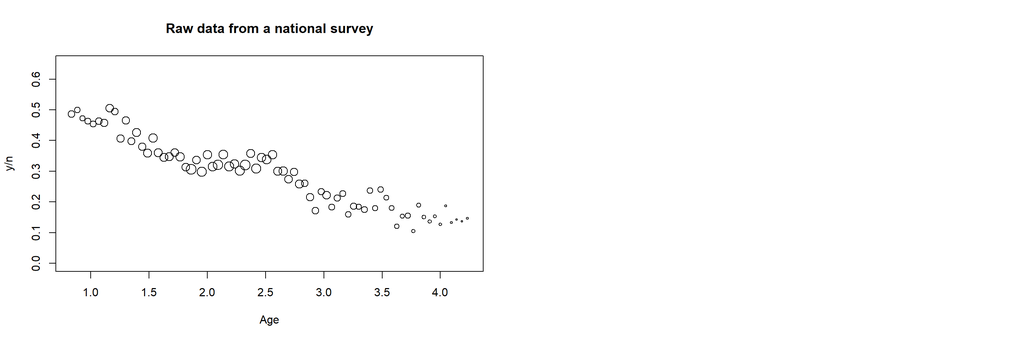

```r
par(mfrow=c(1,2))
plot(gay_sum[[1]]$age/sd(gay_sum[[1]]$age), gay_sum[[1]]$y/gay_sum[[1]]$n, ylim=c(0,.65), xlab="Age", ylab="y/n", type="p", main="Raw data from a national survey", pch=1, cex=2*sqrt(gay_sum[[1]]$n/max(gay_sum[[1]]$n)))
```

Prepare the data to be fitted using the regular Gaussian proccess model and Stan software. The $age$ input variable is scaled by being divided by its standard deviation and renamed as $x$. We choose a set of observations $N1$ for training and another set $N2$ for testing, out of the total number of observations $N$. The objects $ind1$ and $ind2$ contains the indices for the training and test data, respectively.

```r
y <- gay_sum[[1]]$y
n <- gay_sum[[1]]$n
x <- gay_sum[[1]]$age/sd(gay_sum[[1]]$age)

vv2 <- (x>(1.7)&x<(2.3))|x>3.6
ind1= which(!vv2)
ind2= which(vv2)
N1= length(ind1)
N2= length(ind2)
N= length(x)
```

### Gaussian process model

The Stan code for the regular Gaussian process model: ‘https://github.com/gabriuma/basis_functions_approach_to_GP/blob/master/uni_dimensional/gay_dataset/stancode_GP_1dim.stan’

Adjust the model using Stan software and the function ‘stan’ from the R-package ‘rstan’.

```r
stanout_GP <- stan(file= ".../stancode_GP_1dim.stan", data= standata_GP, iter= 3000,  warmup= 2000, chains= 1, thin= 1, algorithm= "NUTS")
```

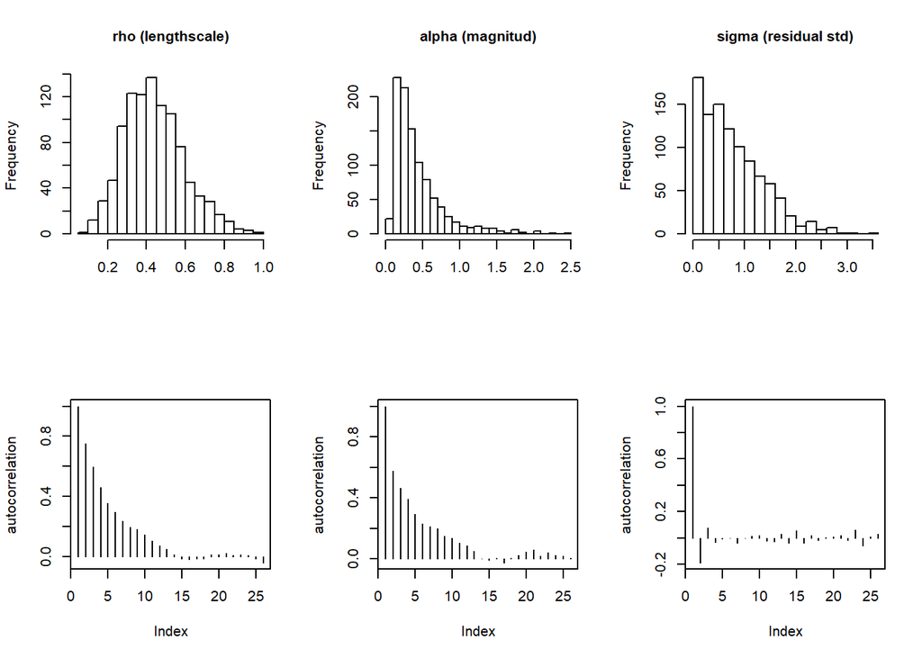

```r
alpha_GP <- summary(stanout_GP, pars = c("alpha"), probs = c(0.025, 0.5, 0.975), digits_summary = 4)$summary
rho_GP <- summary(stanout_GP, pars = c("rho"), probs = c(0.025, 0.5, 0.975), digits_summary = 4)$summary
f_GP <- summary(stanout_GP, pars = c("f"), probs = c(0.025, 0.5, 0.975), digits_summary = 4)$summary
y_predict_GP <- summary(stanout_GP, pars = c("y_predict"), probs = c(0.025, 0.5, 0.975), digits_summary = 4)$summary
log_y_predict_GP <- summary(stanout_GP, pars = c("log_y_predict"), probs = c(0.025, 0.5, 0.975), digits_summary = 4)$summary

par(mfcol=c(2,3))
hist(extract(stanout_GP, pars=c("rho"))$rho, main="rho (lengthscale)", xlab="", cex.lab=1, cex.main=1, breaks=20, cex.main=1)
plot(stan_ac(stanout_GP, pars = c("rho"))$data$ac, type="h", ylab="autocorrelation")
hist(extract(stanout_GP, pars=c("alpha"))$alpha, main="alpha (magnitud)", xlab="", cex.lab=1, cex.main=1, breaks=20, cex.main=1)
plot(stan_ac(stanout_GP, pars = c("alpha"))$data$ac, type="h", ylab="autocorrelation")
hist(extract(stanout_GP, pars=c("sigma"))$sigma, main="sigma (residual std)", xlab="", cex.lab=1, cex.main=1, breaks=20, cex.main=1)
plot(stan_ac(stanout_GP, pars = c("sigma"))$data$ac, type="h", ylab="autocorrelation")
```

Computing the mean square error, the expected log predictive density, the time of computation in seconds per iteration, and the proportion of effective number of samples of some parameters, over the test data:

```r
mse_GP <- sqrt(sum((y[ind2]/n[ind2] - inv.logit(f_GP[ind2]))^2)/N2)
elpd_GP <- sum(log_y_predict_GP[ind2,1])/N2
time_GP <- get_elapsed_time(stanout_GP)[2]/(stanout_GP@sim$iter - stanout_GP@sim$warmup)

neff_alpha_GP <- alpha_GP[,7]/(stanout_GP@sim$iter - stanout_GP@sim$warmup)
neff_rho_GP <- rho_GP[,7]/(stanout_GP@sim$iter - stanout_GP@sim$warmup)
neff_f_GP <- mean(f_GP[,7])/(stanout_GP@sim$iter - stanout_GP@sim$warmup)
neff_sigma_GP <- mean(sigma_GP[,7])/(stanout_GP@sim$iter - stanout_GP@sim$warmup)
```

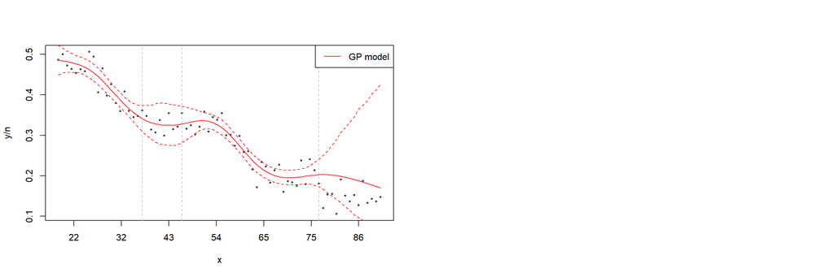

```r
par(mfrow=c(1,2))
plot(x, y/n, cex=0.4, xaxt= "n")
axis(side = 1, at = seq(1,4,0.5), labels = round(seq(1,4,0.5) * sd(gay_sum[[1]]$age)))
matplot(x, inv.logit(f_GP[,c(1,4,6)]), add=TRUE, col=2, type="l", lty=c(1,2,2))
abline(v=c(x[ind2[1]],x[ind2[10]],x[ind1[N1]]), lty=2, col="grey")
legend("topright", legend=c("GP model"), lty=c(1), col=c(2), cex=1)
```

### Basis function approach model

We are going to apply the model based on basis functions to approach the covariance function. First of all, we stablish a collection of different values $M$ for the number of basis functions in the approximation, in order to find out which is the optimal number of basis functions.

```r
M <- c(10,20,30,40,60,80,100)  #different number of basis functions
M
```

```
## [1]  10  20  30  40  60  80 100
```

Different datasets for the Stan software are defined, one for each one of the numbers of basis fucntions (components of M). We establish a set of observations for training $N1$ and another one for test $N2$, out of the total number of observations $N$. The object $ind1$ contains the indices for the training data.

```r
standata_BF <- list()
for(j in 1:length(M)){  #different number of basis functions
    standata_BF[[j]] <- list(M= M[j], L= 5/2*max(x), x= x, y= y, n= n, ind1= ind1, N1= N1, ind2= ind2, N2= N2, N= N)
}
```

The Stan code for this basis function approach model: ‘https://github.com/gabriuma/basis_functions_approach_to_GP/blob/master/uni_dimensional/gay_dataset/stancode_BF_1dim.stan’

Adjust the model using Stan software and the function ‘stan’ from the R-package ‘rstan’. Different adjustments are performed, one for each one of the different numbers of basis functions.

```r
stanout_BF <- list()
for(j in 1:length(M)){  #different number of basis functions
  stanout_BF[[j]] <- stan(file = ".../stancode_BF_1dim.stan", data= standata_BF[[j]], iter= 10000,  warmup= 5000, chains= 1, thin= 1, algorithm= "NUTS", verbose= FALSE)
}
```

Store the results of the hyperparameters $\alpha$ (magnitud) and $\rho$ (lengthscale), the posterior distribution of the latent function $f$, the predictive distribution for training and test data, and the log predictive densities for the test data, in separated vectors and for each one of the different number $M$ of basis functions. Plots of the parameters $rho$ and $alpha$ as a function of the number of basis functions are shown.

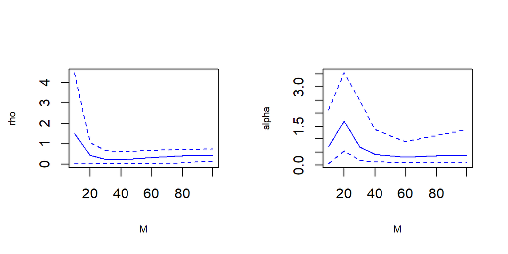

```r
f_BF <- list()
y_predict_BF <- list()
log_y_predict_BF <- list()
rho_BF <- matrix(NA,length(M),8)
alpha_BF <- matrix(NA,length(M),8)

par(mfcol=c(1,2))
for(j in 1:length(M)){  #different number of basis functions
    f_BF[[j]] <- summary(stanout_BF[[j]], pars = c("f"), probs = c(0.025, 0.5, 0.975), digits_summary = 4)$summary
    y_predict_BF[[j]] <- summary(stanout_BF[[j]], pars = c("y_predict"), probs = c(0.025, 0.5, 0.975), digits_summary = 4)$summary
    log_y_predict_BF[[j]] <- summary(stanout_BF[[j]], pars = c("log_y_predict"), probs = c(0.025, 0.5, 0.975), digits_summary = 4)$summary

    rho_BF[j,] <- summary(stanout_BF[[j]], pars = c("rho"), probs = c(0.025, 0.5, 0.975), digits_summary = 4)$summary
    alpha_BF[j,] <- summary(stanout_BF[[j]], pars = c("alpha"), probs = c(0.025, 0.5, 0.975), digits_summary = 4)$summary
}

matplot(M,rho_BF[,c(1,4,6)], xlab="M", type="l", lty=c(1,2,2), col=4, ylab="rho", cex.lab=0.7)
matplot(M,alpha_BF[,c(1,4,6)], xlab="M", type="l", lty=c(1,2,2), col=4, ylab="alpha", cex.lab=0.7)
```

Histogram plots of the parameters $\alpha$ and $\rho$.

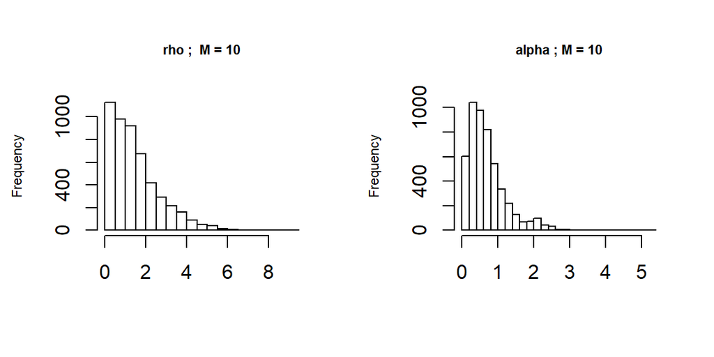

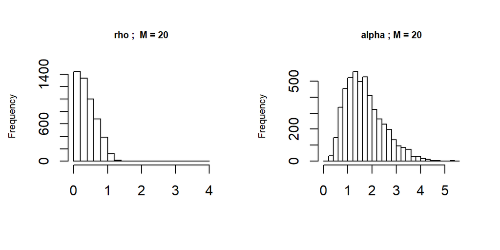

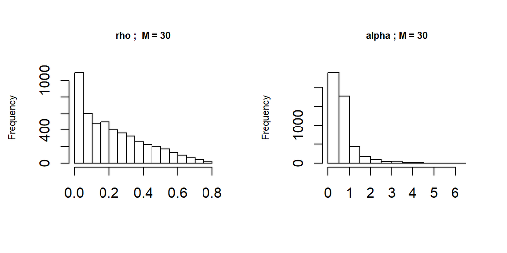

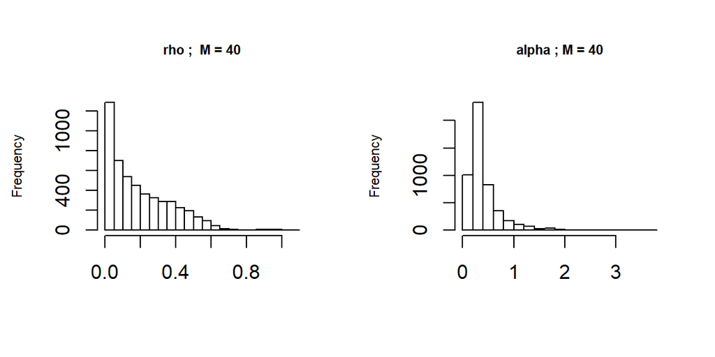

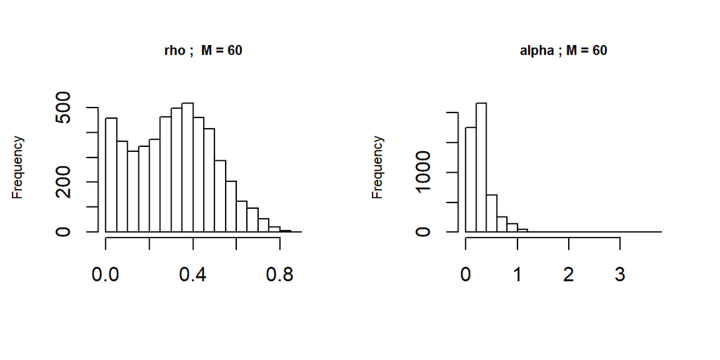

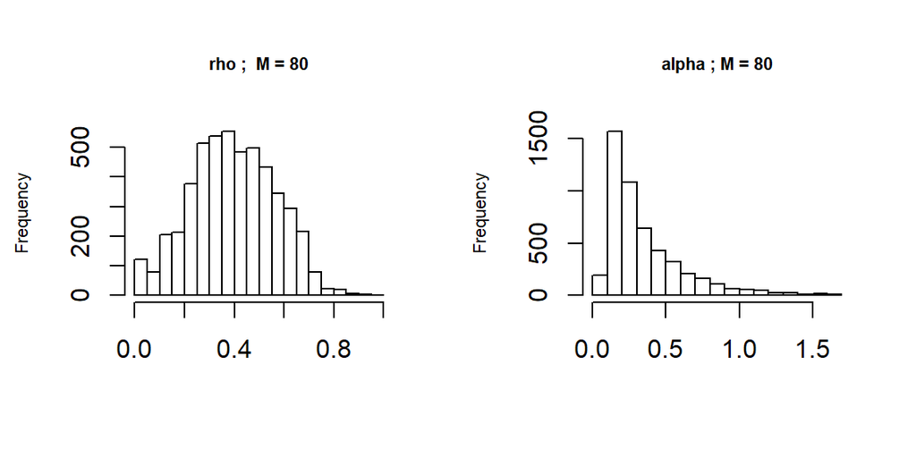

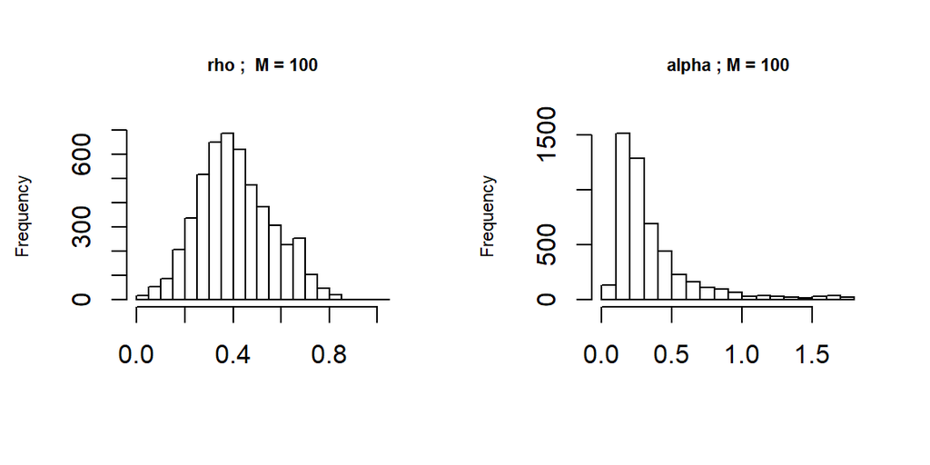

```r
par(mfrow=c(1,2))
for(j in 1:length(M)){
    hist(extract(stanout_BF[[j]], pars=c("rho"))$rho, main=paste("rho ;  M =",M[j]), xlab="", cex.lab=0.7, cex.main=1, breaks=20, cex.main=0.7)
    hist(extract(stanout_BF[[j]], pars=c("alpha"))$alpha, main=paste("alpha ; M =",M[j]), xlab="", cex.lab=0.7, cex.main=1, breaks=20, cex.main=0.7)
}
```

Autocorrelation plots of the parameters $\alpha$ and $\rho$.

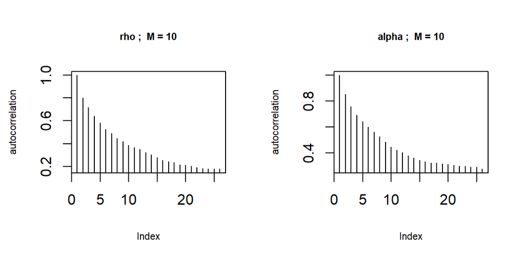

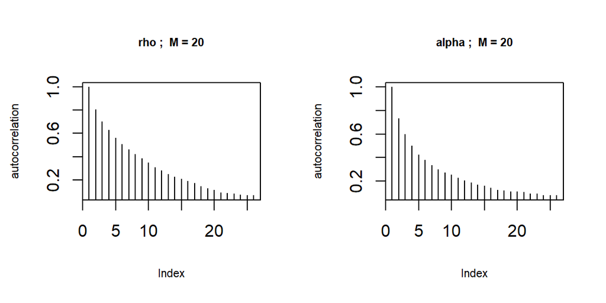

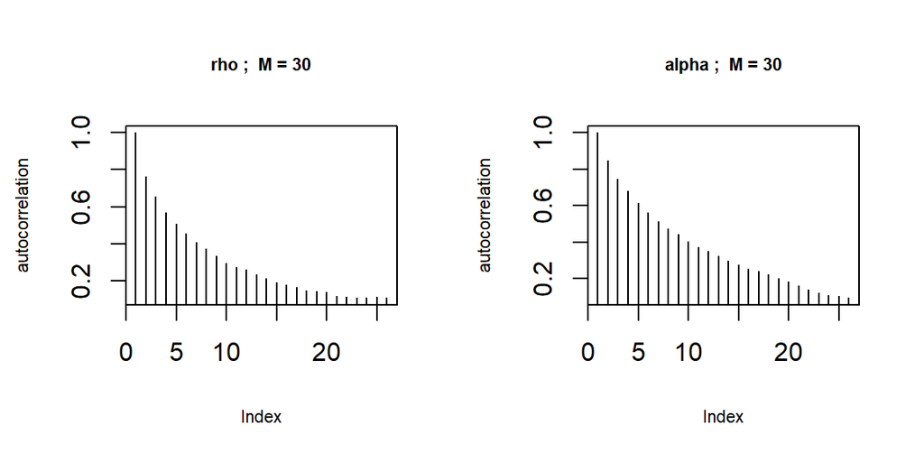

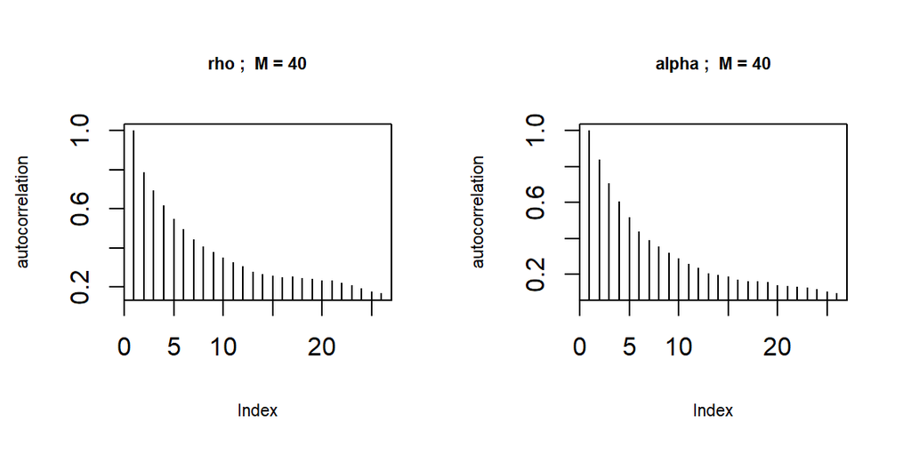

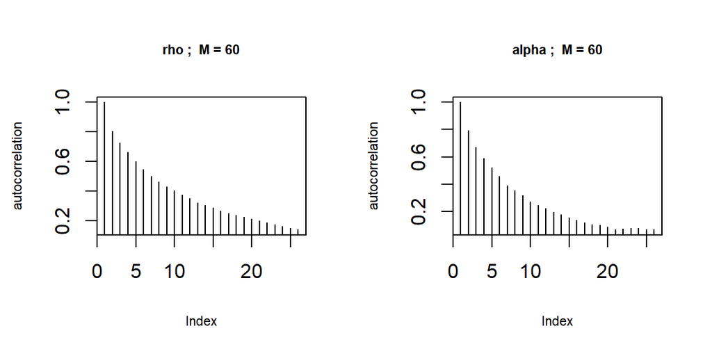

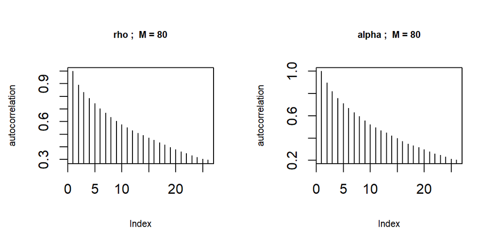

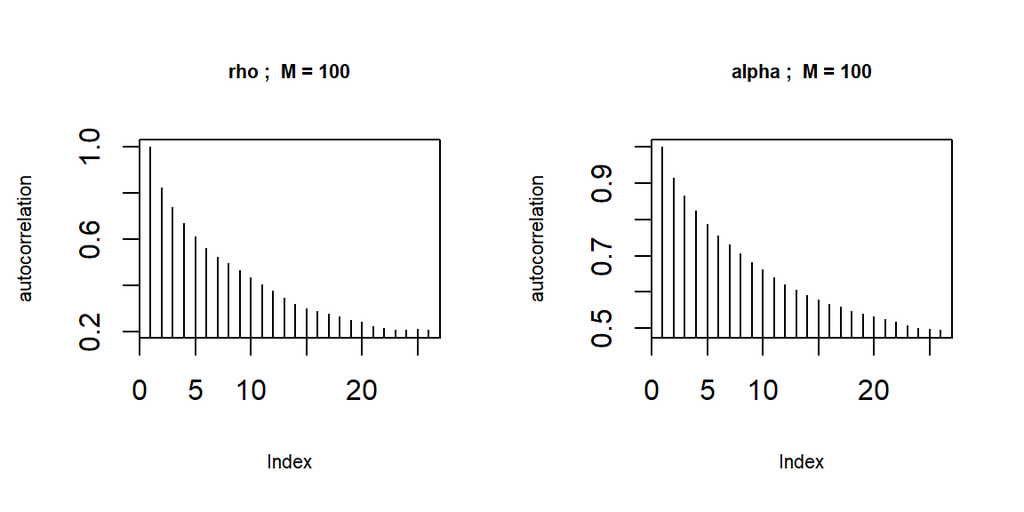

```r
par(mfcol=c(1,2))
for(j in 1:length(M)){
    plot(stan_ac(stanout_BF[[j]], pars = c("rho"))$data$ac, type="h", ylab="autocorrelation", main=paste("rho ;  M =",M[j]), cex.lab=0.7, cex.main=0.7)
    plot(stan_ac(stanout_BF[[j]], pars = c("alpha"))$data$ac, type="h", ylab="autocorrelation", main=paste("alpha ;  M =",M[j]), cex.lab=0.7, cex.main=0.7)
}
```

Computing the mean square error and the expected log predictive density for the test data, the time of computation in seconds per iteration, and the effective number of iterations for the hyperparameters and latent function, as function of the number of basis functions $M$:

```r
mse_BF <- vector()
elpd_BF <- vector()
time_BF <- vector()
mseGP_BF <- vector()
neff_alpha_BF <- vector()
neff_rho_BF <- vector()
neff_f_BF <- vector()

for(j in 1:length(M)){  #different number of basis functions
  mse_BF[j] <- sqrt(sum((y[ind2]/n[ind2] - inv.logit(f_BF[[j]][ind2,1]))^2)/N2)
  elpd_BF[j] <- sum(log_y_predict_BF[[j]][ind2,1])/N2
  time_BF[j] <- get_elapsed_time(stanout_BF[[j]])[2]/(stanout_BF[[j]]@sim$iter - stanout_BF[[j]]@sim$warmup)

  mseGP_BF[j] <- sqrt(sum((inv.logit(f_GP[ind2,1]) - inv.logit(f_BF[[j]][ind2,1]))^2)/N2)

  neff_alpha_BF[j] <- alpha_BF[j,7]/(stanout_BF[[j]]@sim$iter - stanout_BF[[j]]@sim$warmup)
  neff_rho_BF[j] <- rho_BF[j,7]/(stanout_BF[[j]]@sim$iter - stanout_BF[[j]]@sim$warmup)
  neff_f_BF[j] <- mean(f_BF[[j]][,7])/(stanout_BF[[j]]@sim$iter - stanout_BF[[j]]@sim$warmup)
}
```

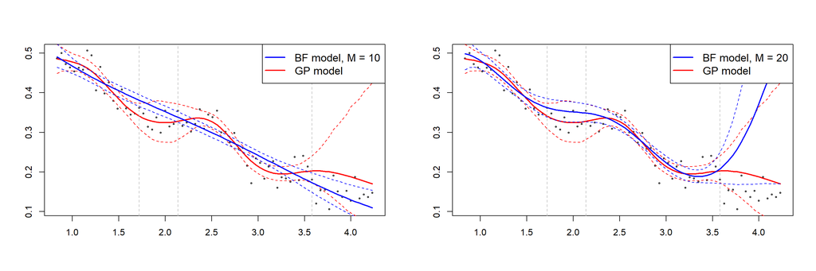

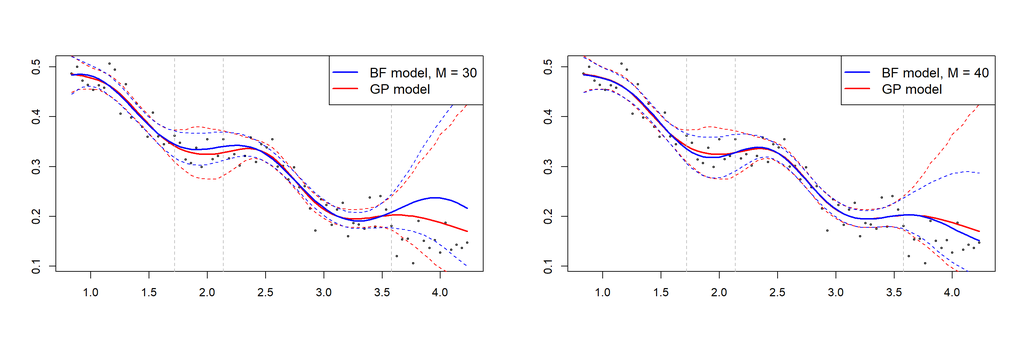

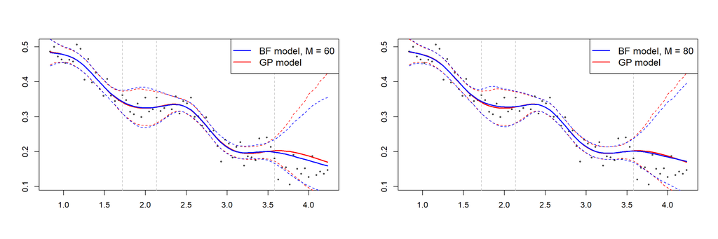

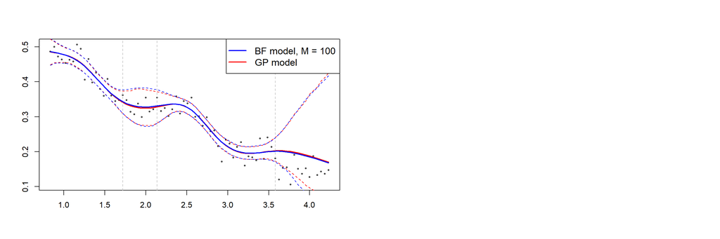

```r
par(mfrow=c(1,2))
for(j in 1:length(M)){  #different number of basis functions
  plot(x, y/n, cex=0.4, xlab="",ylab="",cex.axis=1)
    matplot(x, inv.logit(f_GP[,c(1,4,6)]), add=TRUE, col=2, type="l", lty=c(1,2,2), lwd=c(2,1,1))
  abline(v=c(x[ind2[1]],x[ind2[10]],x[ind1[N1]]), lty=2, col="grey")

  matplot(x, inv.logit(f_BF[[j]][,c(1,4,6)]), add=TRUE, col=4, type="l", lty=c(1,2,2), lwd=c(2,1,1))

    legend("topright", legend=c(paste("BF model, M =",M[j]),"GP model"), lty=c(1), lwd=c(2), pch=c(NA), pt.cex=c(NA), col=c(4,2), cex=1.2)
}
```

The following figure shows the estimated aproximate covariance function for the different numbers $M$ of basis functions :

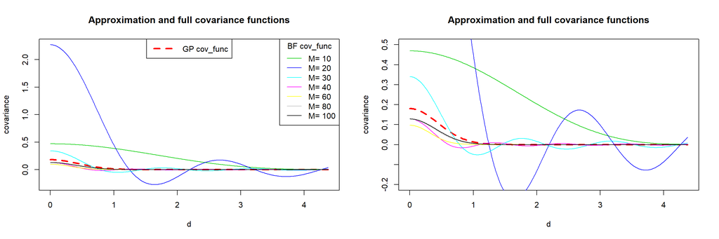

```r
L <- 5/2*max(x)

d <- seq(0,rho_GP[,1]*10,0.01)
cov_BF <- matrix(NA, length(d), length(M))
for(m in 1:length(M)){
    for(i in 1:length(d)){
        cov_BF[i,m] <- covfun_BF(M[m], alpha_BF[m,1], rho_BF[m,1], L, d[i])
    }
}

par(mfrow=c(1,2))
plot(d, cov_GP(alpha_GP[,1], rho_GP[,1], d), col=2, lwd=3, lty=2, type="l", ylim=c(min(cov_BF),max(cov_BF)), ylab="covariance", main="Approximation and full covariance functions")
matplot(d, cov_BF, type="l", add=TRUE, col=c(3:(2+length(M))), lty=1, lwd=1)

legend("topright", legend=paste("M=",as.character(M)), col=c(3:(2+length(M))), lty=1, lwd=1, title="BF cov_func", cex=1)
legend("top", legend="GP cov_func", col=2, lty=2, lwd=3, cex=1, seg.len= 3)

plot(d, cov_GP(alpha_GP[,1], rho_GP[,1], d), col=2, lwd=3, lty=2, type="l", ylim=c(-0.2,0.5), ylab="covariance", main="Approximation and full covariance functions")
matplot(d, cov_BF, type="l", add=TRUE, col=c(3:(2+length(M))), lty=1, lwd=1)
```

### Smooth splines model

We are going to fit a smooth spline model (using function ‘s’ of the R-package ’mgcv) in order to do comparison to the Basis function approach.

Following, the function ‘make_standata’ of the R-package ‘brms’ is used to obtain different datasets, one for each one of the different number $kn$ of knots, for this smooth spline model.

```r
kn <- c(2,3,4,6,8,10,15,20)  #different number of knots

standata_SP <- list()
for(j in 1:length(kn)){  #different number of knots
    standata_SP[[j]] <- make_standata(y | trials(n) ~ s(x, k=2+kn[j]), family = binomial("logit"), data.frame(x= x, y= y, n= n))
    standata_SP[[j]]$N1 <- N1
    standata_SP[[j]]$ind1 <- ind1
}
```

In the same way, the function ‘make_stancode’ of the R-package ‘brms’ is used to build the main body of the Stan code for this smooth spline model.

```r
stancode_SP <- make_stancode(y | trials(n) ~ s(x, k=2+kn[j]), family = binomial("logit"), data.frame(x= x, y= y, n= n))
```

Then, the code is polished to adapt it to the data, yielding to the final code: ‘https://github.com/gabriuma/basis_functions_approach_to_GP/blob/master/uni_dimensional/gay_dataset/stancode_SP_1dim.stan’

Adjust the model using Stan software and the function ‘stan’ from the R-package ‘rstan’. Different adjustments are performed, one for each one of the different numbers of knots.

```r
stanout_SP <- list()
for(j in 1:length(kn)){  #different number of knots
  stanout_SP[[j]] <- stan(file = ".../stancode_SP_1dim.stan", data= standata_SP[[j]], iter = 10000,  warmup = 5000, chains=1, thin=1, algorithm = "NUTS")
}
```

Storing marginal posterior and predictive distribution of parameters.

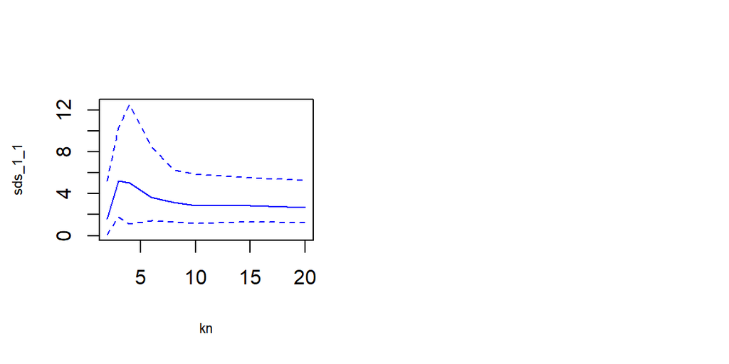

```r
f_SP <- list()
y_SP <- list()
log_y_SP <- list()
time_SP <- list()
zs_1_1_SP <- list()
sds_1_1_SP <- matrix(NA,length(kn),8)

par(mfcol=c(1,2))
for(j in 1:length(kn)){  #different number of knots
  f_SP[[j]] <- summary(stanout_SP[[j]], pars = c("mu"), probs = c(0.025, 0.5, 0.975), digits_summary = 4)$summary
  y_SP[[j]] <- summary(stanout_SP[[j]], pars = c("y_predict"), probs = c(0.025, 0.5, 0.975), digits_summary = 4)$summary
  log_y_SP[[j]] <- summary(stanout_SP[[j]], pars = c("log_y_predict"), probs = c(0.025, 0.5, 0.975), digits_summary = 4)$summary

    time_SP[[j]] <- sum(get_elapsed_time(stanout_SP[[j]])[2])/(stanout_SP[[j]]@sim$iter - stanout_SP[[j]]@sim$warmup)
  zs_1_1_SP[[j]] <- summary(stanout_SP[[j]], pars = c("zs_1_1"), probs = c(0.025, 0.5, 0.975), digits_summary = 4)$summary
  sds_1_1_SP[j,] <- summary(stanout_SP[[j]], pars = c("sds_1_1"), probs = c(0.025, 0.5, 0.975), digits_summary = 4)$summary
}

matplot(kn,sds_1_1_SP[,c(1,4,6)], xlab="kn", type="l", lty=c(1,2,2), col=4, ylab="sds_1_1", cex.lab=0.7)
```

Histogram plots of the parameter $sds_1_1$.

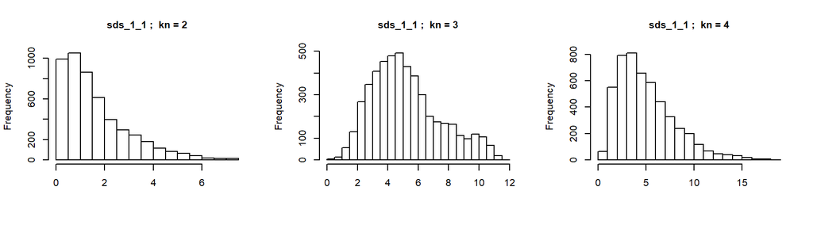

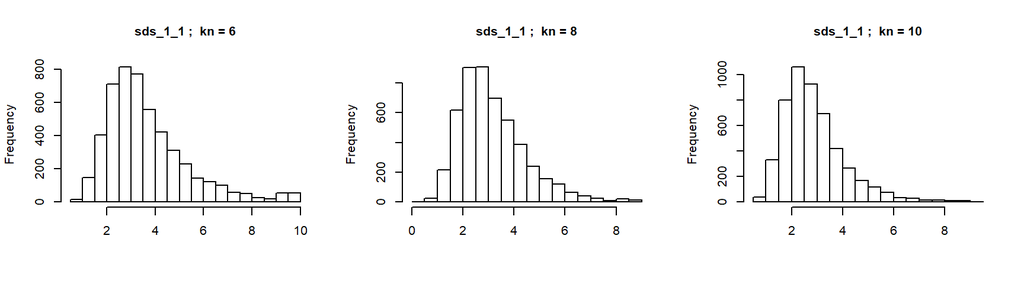

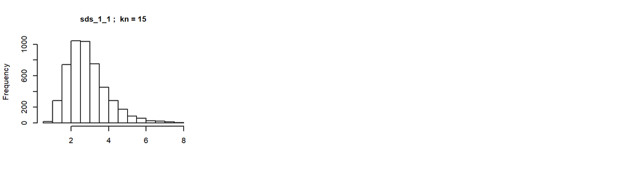

```r
par(mfrow=c(1,3))
for(j in 1:length(M)){
    hist(extract(stanout_SP[[j]], pars=c("sds_1_1"))$sds_1_1, main=paste("sds_1_1 ;  kn =",kn[j]), xlab="", cex.lab=1, cex.main=1, breaks=20)
}
```

Autocorrelation plots of the parameter $sds_1_1$.

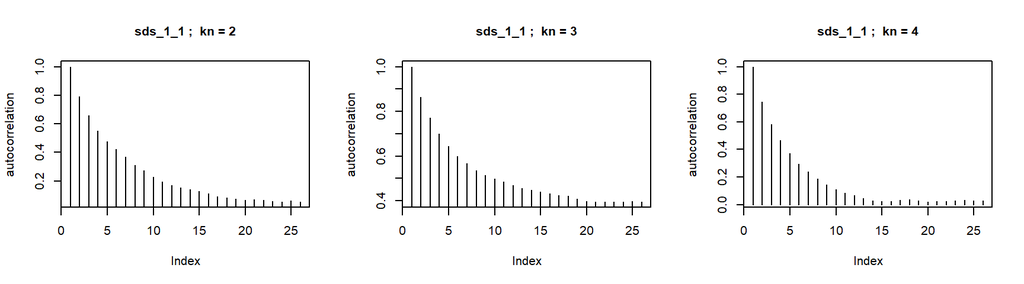

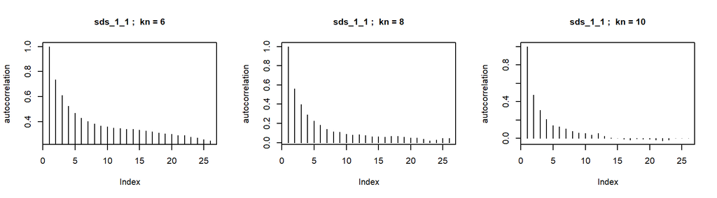

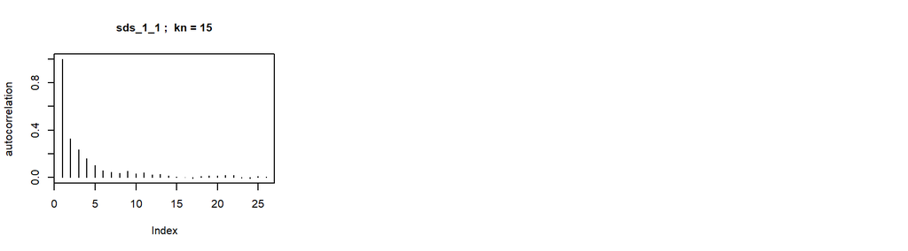

```r
par(mfcol=c(1,3))
for(j in 1:length(M)){
    plot(stan_ac(stanout_SP[[j]], pars = c("sds_1_1"))$data$ac, type="h", ylab="autocorrelation", main=paste("sds_1_1 ;  kn =",kn[j]), cex.main=1, cex.lab=1)
}
```

Computing the mean square error and the expected log predictive density for the test data, the time of computation in seconds per iteration, and the effective number of iteratons for the hyperparameters and latent function, as function of the number of basis functions $M$:

```r
mse_SP <- vector()
elpd_SP <- vector()
time_SP <- vector()
neff_sds_1_1_SP <- vector()
neff_f_GP <- vector()

for(j in 1:length(kn)){  #different number of knots
  mse_SP[j] <- sqrt(sum((y[ind2]/n[ind2] - inv.logit(f_SP[[j]][ind2]))^2)/N2)
  elpd_SP[j] <- sum(log_y_SP[[j]][ind2,1])/N2
  time_SP[j] <- sum(get_elapsed_time(stanout_SP[[j]])[2])/(stanout_SP[[j]]@sim$iter - stanout_SP[[j]]@sim$warmup)

  neff_sds_1_1_SP[j] <- sds_1_1_SP[j,7]/(stanout_SP[[j]]@sim$iter - stanout_SP[[j]]@sim$warmup)
  neff_f_SP[j] <- mean(f_SP[[j]][,7])/(stanout_SP[[j]]@sim$iter - stanout_SP[[j]]@sim$warmup)
}
```

Plot of the posterior distribution for the laten function, using different values $kn$ of the number of knots. The vertical grey dashed line divide the training and test data sets.

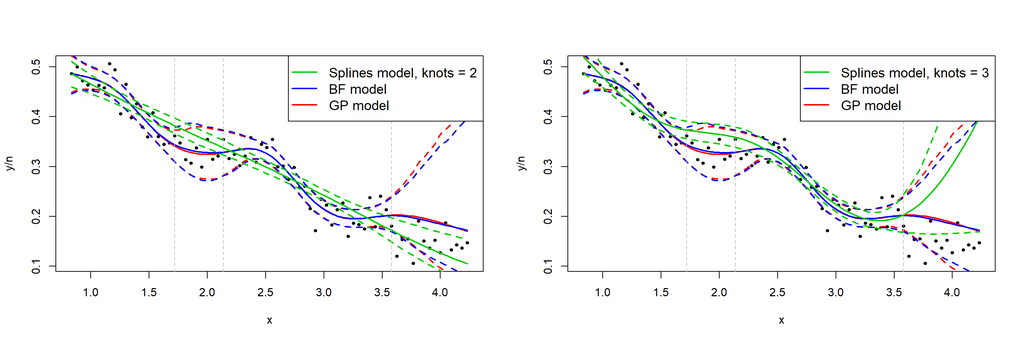

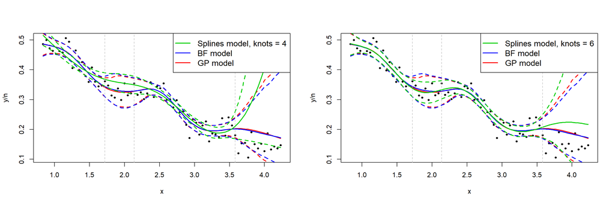

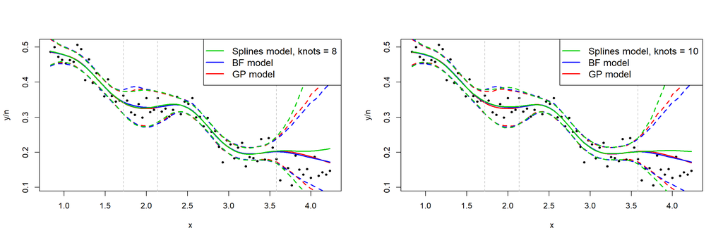

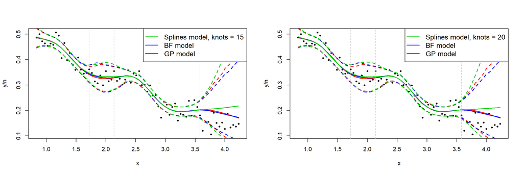

```r
par(mfrow=c(1,2))
for(j in 1:length(kn)){  #different number of knots
  plot(x, y/n, cex=0.6, pch= 19,  xlab="x",ylab="y/n",cex.axis=1)
  matplot(x, inv.logit(f_GP[,c(1,4,6)]), add=TRUE, col=2, lwd=2, lty=c(1,2,2), type="l")
  matplot(x, inv.logit(f_BF[[6]][,c(1,4,6)]), add=TRUE, col=4, lwd=2, lty=c(1,2,2), type="l")
  matplot(x, inv.logit(f_SP[[j]][,c(1,4,6)]), add=TRUE, col="green3", lwd=2, lty=c(1,2,2), type="l")
  abline(v=c(x[ind2[1]],x[ind2[10]],x[ind1[N1]]), lty=2, col="grey")
  legend("topright", legend=c(paste("Splines model, knots =",kn[j]),"BF model","GP model"), lty=c(1), lwd=c(2), pch=c(NA), pt.cex=c(NA), col=c("green3",4,2), cex=1.2)
}
```

### MSE, ELPD, computation time and effective number of samples

Mean square error as a function of the number of basis functions in the case of the Basis function model, and as a function of knots in the case of the Splines model.

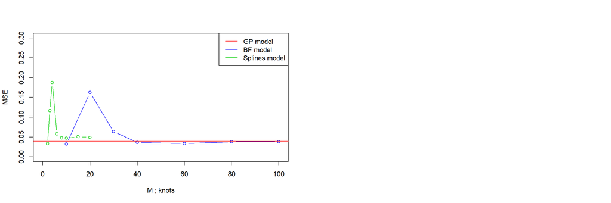

```r
par(mfrow=c(1,2))

#SP model
matplot(kn, mse_SP[1:length(kn)], type="b", col="green3", lwd=1, lty=1, pch=1, ylim=c(0,0.30), xlab="M ; knots", ylab="MSE", xlim=c(0,100))
#BF model
matplot(M, mse_BF[1:length(M)], type="b", col=4, lwd=1, lty=1, pch=1, add= TRUE)
#GP model
abline(h= mse_GP, col=2, lwd=1, lty=1)

legend("topright", legend=c("GP model","BF model","Splines model"), col=c(2,4,"green3"), lty=c(1,1,1), lwd=1)
```

Expected log predictive density as a function of the number of basis functions, in the case of the Basis function model, and as a function of knots, in the case of the Splines model.

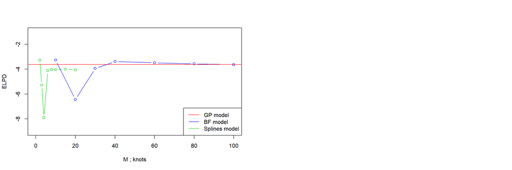

```r
par(mfrow=c(1,2))

matplot(kn, elpd_SP[1:length(kn)], type="b", col="green3", lwd=1, lty=1, pch=1,ylim=c(-9,-1),xlab="M ; knots", ylab="ELPD", xlim=c(0,100))

matplot(M, elpd_BF[1:length(M)], type="b", col=4, lwd=1, lty=1, pch=1, ylim=c(-15,4), add=TRUE)

abline(h= elpd_GP, col=2, lwd=1, lty=1)

legend("bottomright", legend=c("GP model","BF model","Splines model"), col=c(2,4,"green3"), lty=c(1,1,1), lwd=1)
```

Time-consuming of the models as a function of the number of basis functions in the case of the Basis functions model, and as a function of the knots in the case of the Splines model.

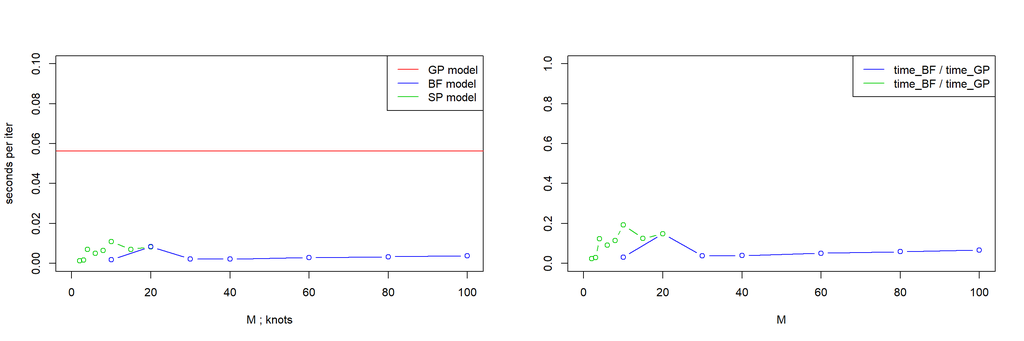

```r
par(mfrow=c(1,2))

matplot(kn, time_SP[1:length(kn)], type="b", col="green3", lwd=1, lty=1, pch=1,xlab="M ; knots", ylab="seconds per iter", ylim=c(0,0.1), xlim=c(0,100))
matplot(M, time_BF[1:length(M)], type="b", col=4, lty=1, pch=1, add=TRUE)
abline(h= time_GP, col=2, lty=1)

legend("topright", legend=c("GP model","BF model","SP model"), col=c(2,4,"green3"), lty=c(1,1,1), lwd=1)

matplot(M, time_BF[1:length(M)]/time_GP, type="b", col=4, lty=1, pch=1, ylab="", xlab="M", xlim=c(0,100), ylim=c(0,1))
matplot(kn, time_SP[1:length(kn)]/time_GP, type="b", col="green3", lty=1, pch=1, ylab="time_SP / time_GP", xlab="knots", xlim=c(0,100), ylim=c(0,1), add=TRUE)

legend("topright", legend=c("time_BF / time_GP", "time_BF / time_GP"), col=c(4,"green3"), lty=c(1), lwd=1)
```

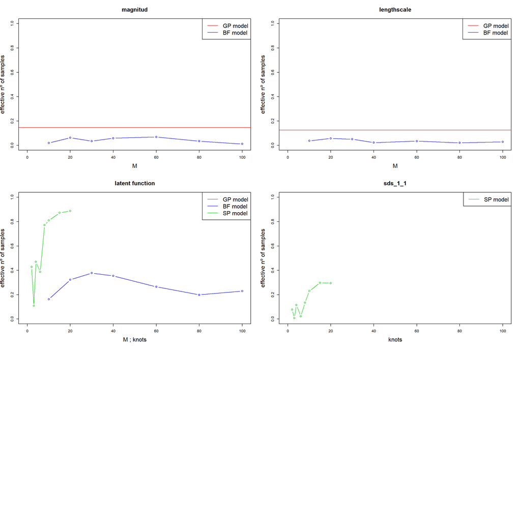

```r
par(mfrow=c(3,2))
# alpha (magnitud)
matplot(M, neff_alpha_BF[1:length(M)], type="b", col=4, lwd=1, lty=1, pch=1, ylim=c(0,1), ylab="effective nº of samples", main="magnitud", xlab="M", xlim=c(0,100), cex.lab=1.5, cex.main=1.5)
abline(h= neff_alpha_GP, col=2, lwd=1, lty=1)
legend("topright", legend=c("GP model","BF model"), col=c(2,4,"green3"), lty=c(1,1,1), lwd=1, cex=1.5)

# rho (lengthscale)
matplot(M, neff_rho_BF[1:length(M)], type="b", col=4, lwd=1, lty=1, pch=1, ylim=c(0,1), ylab="effective nº of samples", main="lengthscale", xlab="M", xlim=c(0,100), cex.lab=1.5, cex.main=1.5)
abline(h= neff_rho_GP, col=2, lwd=1, lty=1)
legend("topright", legend=c("GP model","BF model"), col=c(2,4,"green3"), lty=c(1,1,1), lwd=1, cex=1.5)

# latent function f
matplot(M, neff_f_BF[1:length(M)], type="b", col=4, lwd=1, lty=1, pch=1, ylim=c(0,1), ylab="effective nº of samples", main="latent function", xlab="M ; knots", xlim=c(0,100), cex.lab=1.5, cex.main=1.5)
matplot(kn[1:8], neff_f_SP[1:length(kn[1:8])], type="b", col="green3", lwd=1, lty=1, pch=1,add=TRUE)
abline(h= neff_f_GP, col=2, lwd=1, lty=1)
legend("topright", legend=c("GP model","BF model","SP model"), col=c(2,4,"green3"), lty=c(1,1,1), lwd=1, cex=1.5)

# sds_1_1
matplot(kn, neff_sds_1_1_SP[1:length(kn)], type="b", col="green3", lwd=1, lty=1, pch=1, ylim=c(0,1), ylab="effective nº of samples", main="sds_1_1", xlab="knots", xlim=c(0,100), cex.lab=1.5, cex.main=1.5)
legend("topright", legend=c("SP model"), col=c("green3"), lty=c(1,1,1), lwd=1, cex=1.5)
```